# exploratory_network_analysis

Pietro Olivetti, Max Comerma, Maria Barraza

2024-07-29

Questions: - How should I approach the sociodemographic data? - Should the values be transformed (Min-Max, Normalization)? - Which variables? Only the centrality measures? - How to explore clusters?

# Network analysis of Depression and Anxiety Symptomatology

[Reference article](https://www.frontiersin.org/journals/psychology/articles/10.3389/fpsyg.2018.01742/full)

## Packages and loading

```r
library(dplyr)
library(igraph)
library(igraphdata)
library(qgraph)
library(bootnet)
library(corpcor)
library(usethis)
library(MPsychoR)
library(openxlsx)
library(ggplot2)
library(tidyr)
library(png)
library(gridExtra)
library(smacof)
df <- read.csv('../data/data_cleaned.csv')[2:215]
```

## Grouping variables

Ids = 1, Sociodem = 2:8, Pers_BFI2 = 9:23, Pers_hexaco = 24:33, Depr_cesd = 34:53, Depr_phq = 54:63, Depr_promis = 64:91, Depr_qids = 92:108, Depr_Ans_dass = 108:128, Depr_Ans_hads = 129:142, Ans_gad = 143:149, Ans_tmas = 150:199, Ans_sas = 200:214

## Force-directed plotting with Fruchterman–Reingold

Most studies on networks in psychopathology have used the Fruchterman-Reingold (FR) algorithm to create graphs. This algorithm is like setting up a system of balls connected by stretchy strings. The strings pull connected balls closer, while the other balls push them apart, resulting in a neat graph where nodes are well-spaced and edges are evenly distributed.

Force-directed algorithms aim to produce visually pleasing graphs by minimizing edge crossings and spacing nodes evenly. The goal is not to place the nodes in specific meaningful locations, but to make the network easy to view, showing connections and clusters clearly.

It’s important to avoid interpreting the spatial positions of nodes in these graphs, as the placement is not meant to convey specific meanings. Misinterpreting the layout is a common mistake, as it’s natural to want to find meaning in the arrangement.

The FR algorithm is the default in the qgraph R package, making it straightforward to use.

### Creating individual scales networks using FR algorithm

These individual networks sho the connetions between the items.

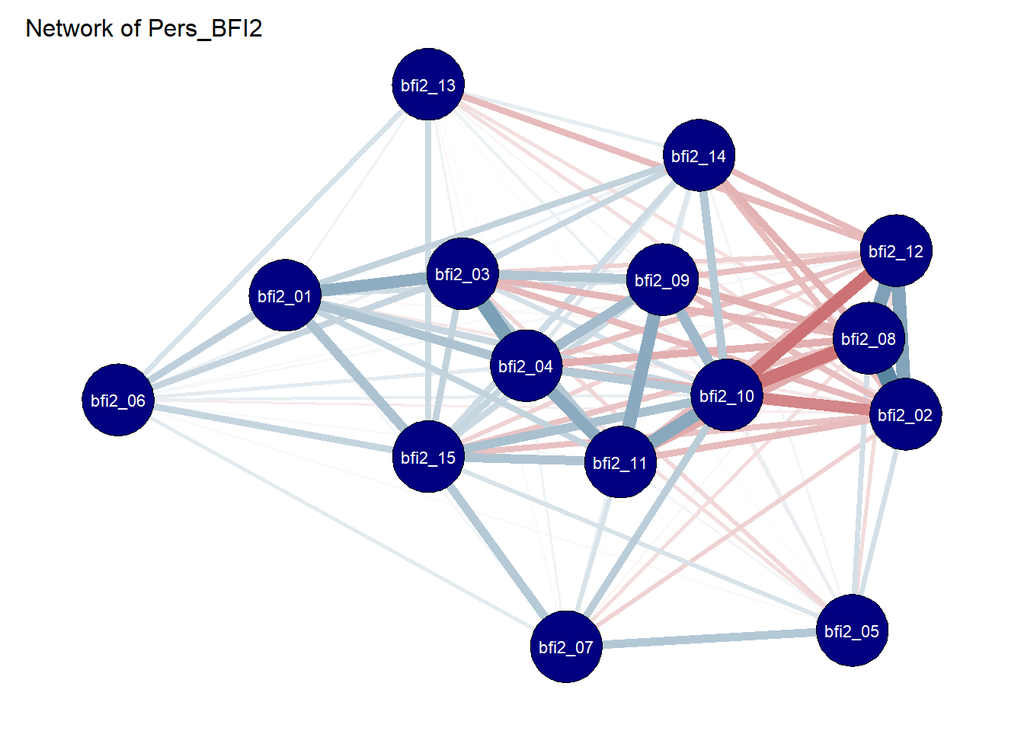

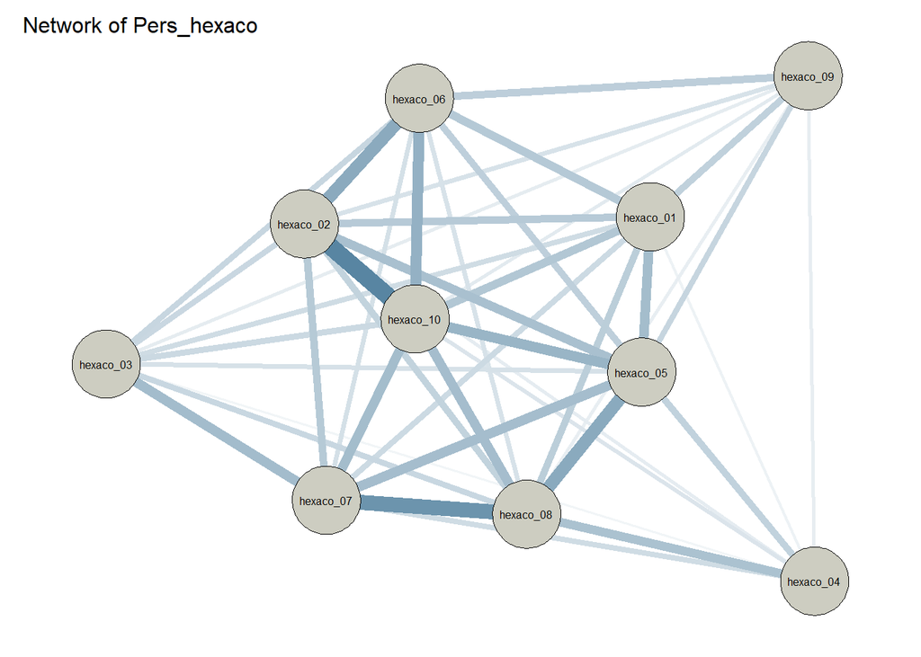

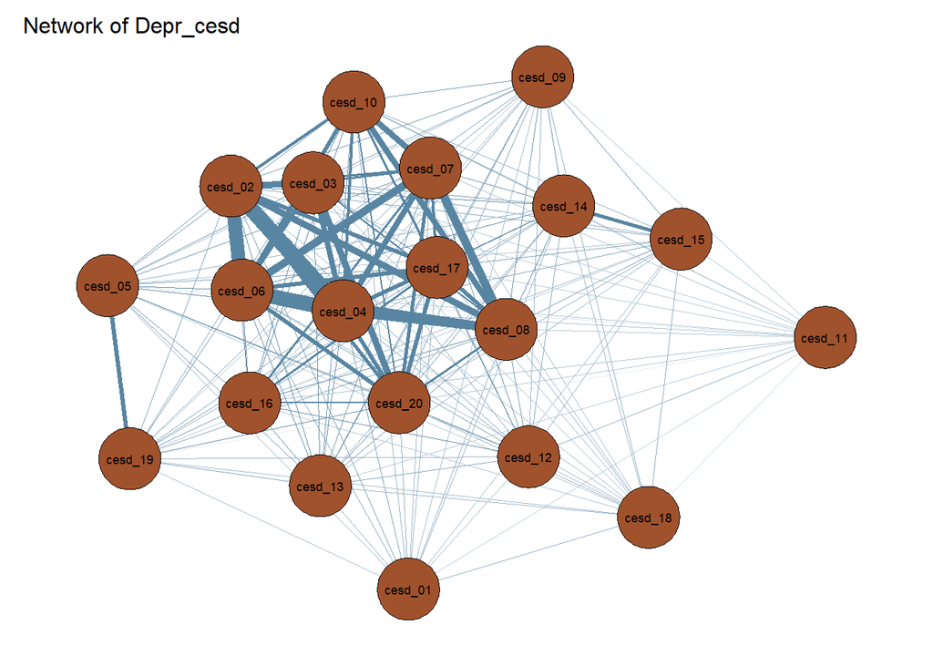

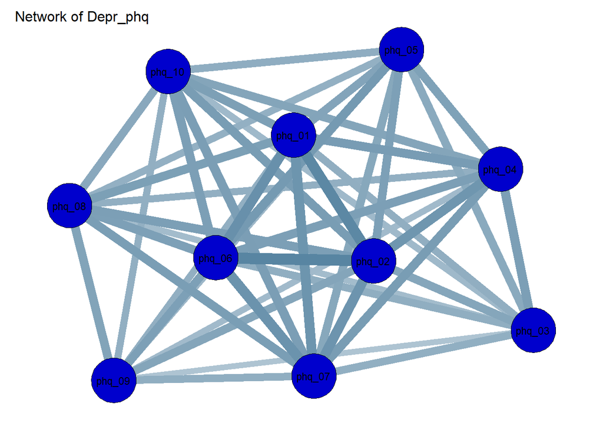

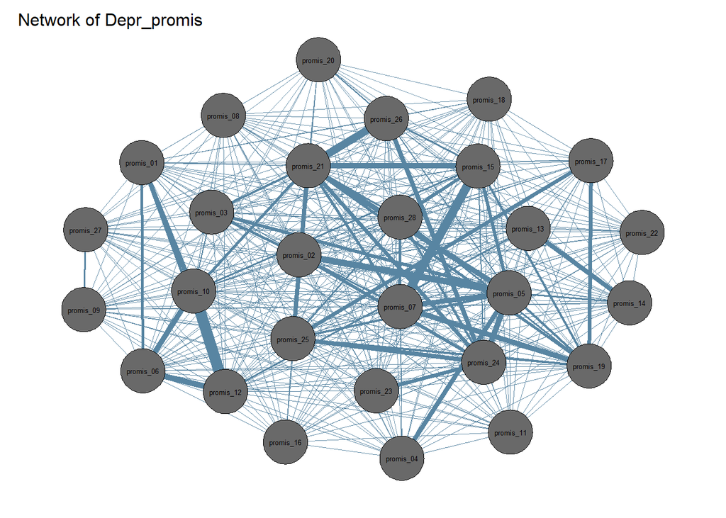

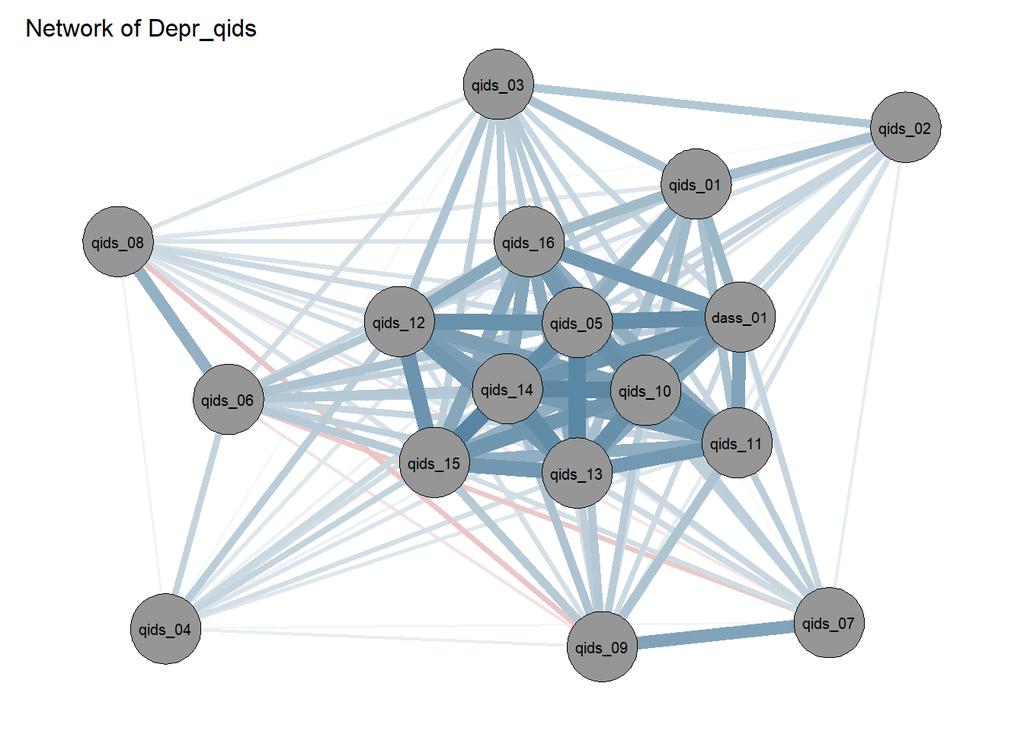

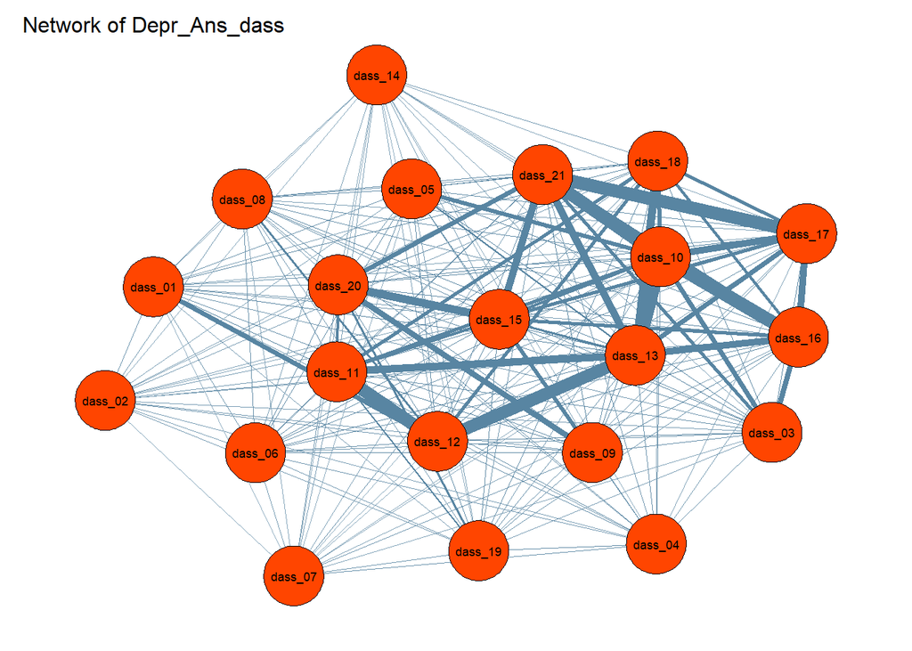

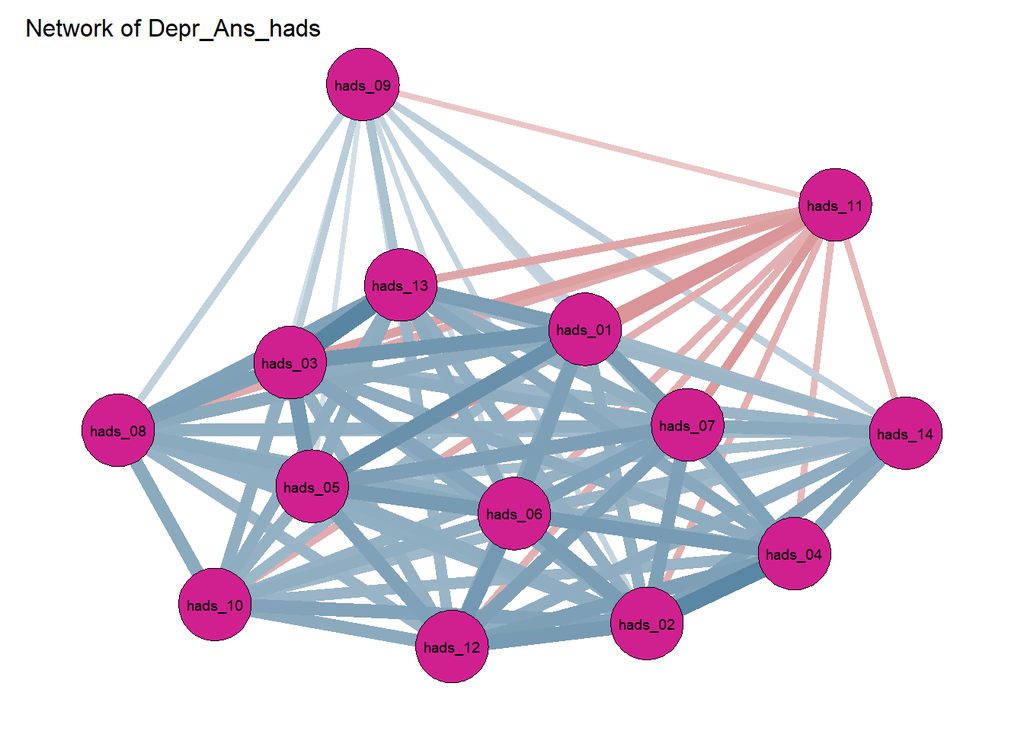

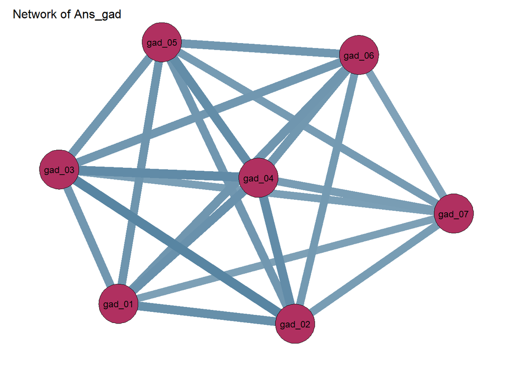

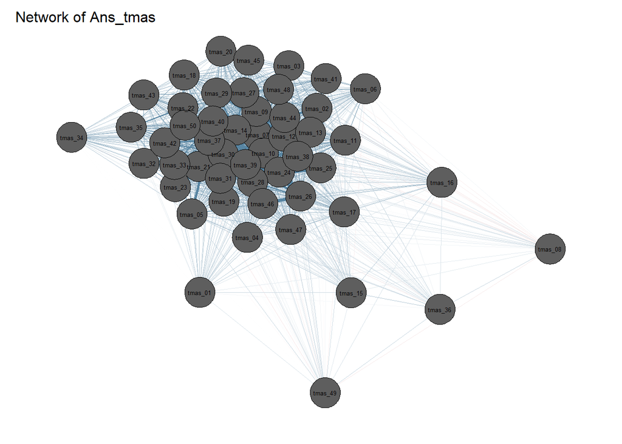

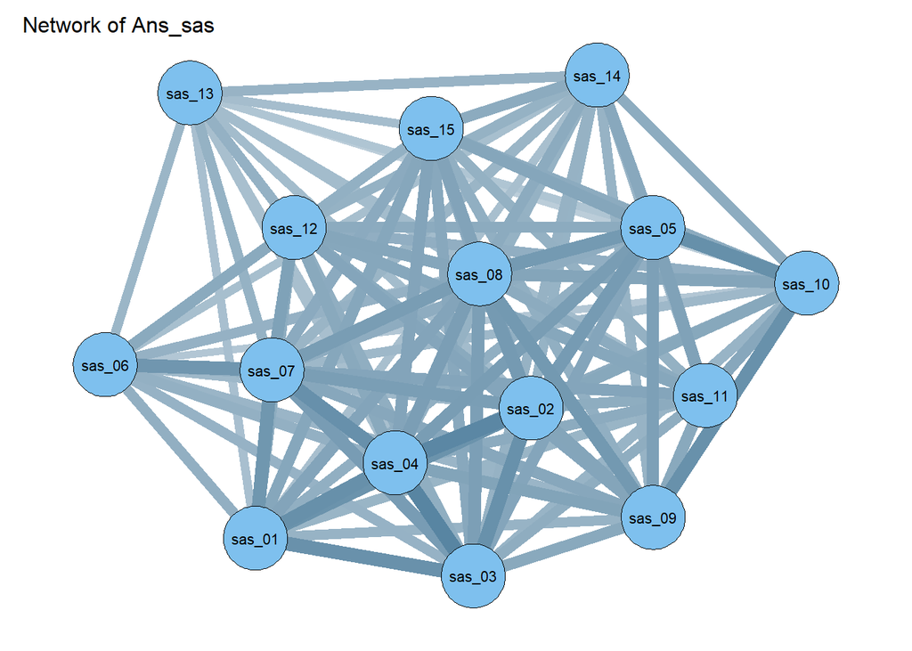

```r
groups <- list(Pers_BFI2 = 9:23, Pers_hexaco = 24:33, Depr_cesd = 34:53, Depr_phq = 54:63, Depr_promis = 64:91, Depr_qids = 92:108, Depr_Ans_dass = 108:128, Depr_Ans_hads = 129:142, Ans_gad = 143:149, Ans_tmas = 150:199, Ans_sas = 200:214)

group_names <- c("Ids", "Sociodem", "Pers_BFI2", "Pers_hexaco", "Depr_cesd", "Depr_phq", "Depr_promis", "Depr_qids", "Depr_Ans_dass", "Depr_Ans_hads", "Ans_gad", "Ans_tmas", "Ans_sas")

n <- 3
for(sc in groups){
  zero_order <- cor(df[sc])
  qgraph(zero_order, layout="spring", labels = colnames(zero_order), color = sample(colors(), 1), theme="TeamFortress", height = 180, width = 140, title = paste("Network of", group_names[n]))
  n <- n + 1
}
```

### All the scales

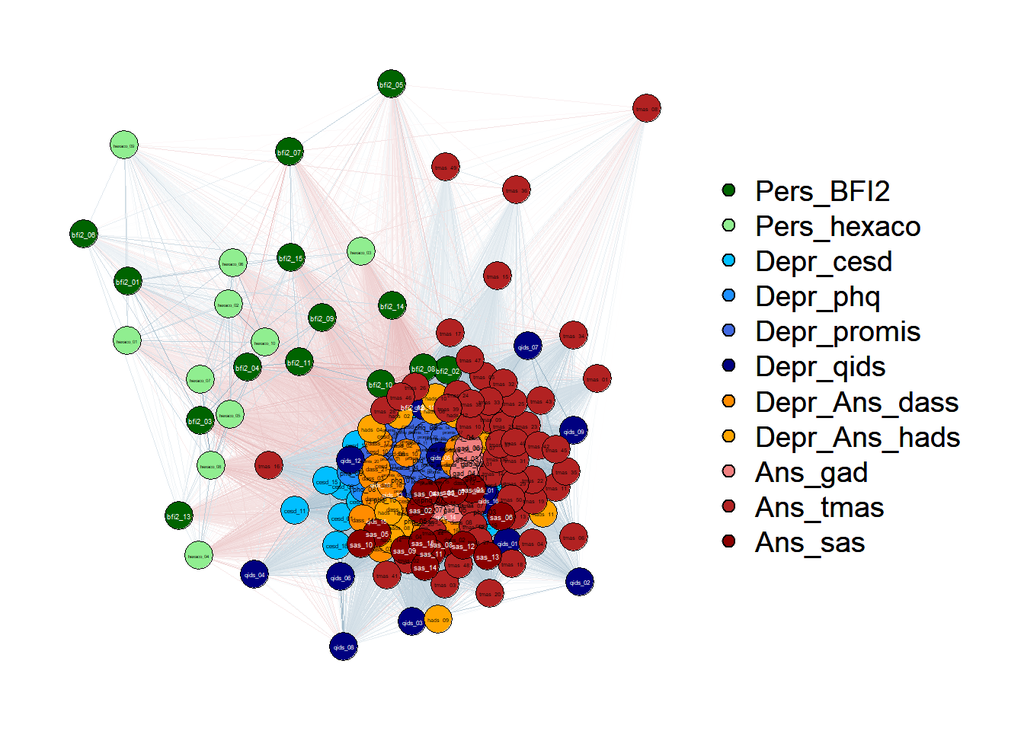

```r
groups <- list(Pers_BFI2 = 1:15, Pers_hexaco = 16:25, Depr_cesd = 26:45, Depr_phq = 46:55, Depr_promis = 56:83, Depr_qids = 84:100, Depr_Ans_dass = 101:120, Depr_Ans_hads = 121:134, Ans_gad = 135:141, Ans_tmas = 142:191, Ans_sas = 192:206)


color_nodes <- c("darkgreen", "lightgreen", "deepskyblue", "dodgerblue", "royalblue", "navy", "darkorange", "orange", "lightcoral", "firebrick", "darkred")


gen_zeroorder <- cor(df[9:214])

qgraph(gen_zeroorder, layout="spring", labels = colnames(gen_zeroorder), groups = groups , color = color_nodes, theme="TeamFortress", height = 180, width = 140, vsize=3)
```

### Only the scales related to anxiety and depression

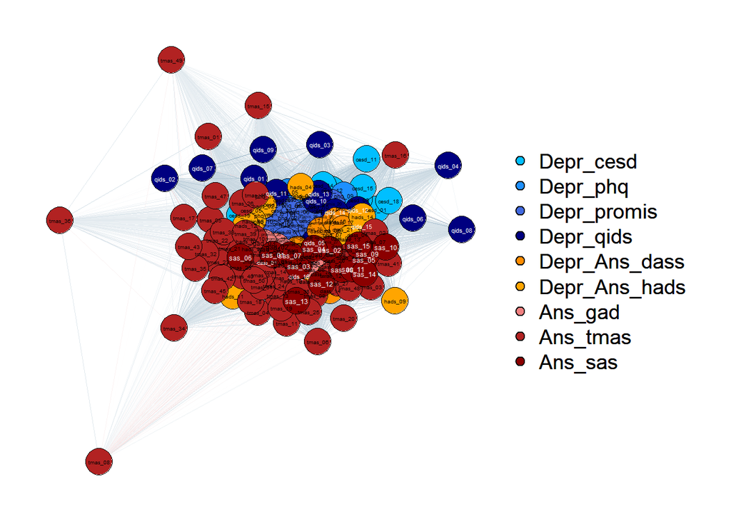

```r
groups_anx_dep <- list(Depr_cesd = 1:20, Depr_phq = 21:30, Depr_promis = 31:58, Depr_qids = 59:75, Depr_Ans_dass = 76:95, Depr_Ans_hads = 96:109, Ans_gad = 110:116, Ans_tmas = 117:166, Ans_sas = 167:181)

color_nodes_anx_dep <- c("deepskyblue", "dodgerblue", "royalblue", "navy", "darkorange", "orange", "lightcoral", "firebrick", "darkred")


symp_zeroorder <- cor(df[34:214])
qgraph(symp_zeroorder, layout="spring", labels = colnames(symp_zeroorder), groups = groups_anx_dep , color = color_nodes_anx_dep, theme="TeamFortress", height = 180, width = 140, vsize=4)
```

### Networks of the top n measures of centrality

#### All Scales

Let’s explore measures of centrality such as Degree, Betweenness and Closeness by sorting the n=25 top results for each measure and creating a Network for each of them

```r
all_cent_measures_25_top <- FR_net_by_scales_topnum_measures(df, list(Sociodem = 2:8, Pers_BFI2 = 9:23, Pers_hexaco = 24:33, Depr_cesd = 34:53, Depr_phq = 54:63, Depr_promis = 64:91, Depr_qids = 92:108, Depr_Ans_dass = 108:128, Depr_Ans_hads = 129:142, Ans_gad = 143:149, Ans_tmas = 150:199, Ans_sas = 200:214), 25)
```

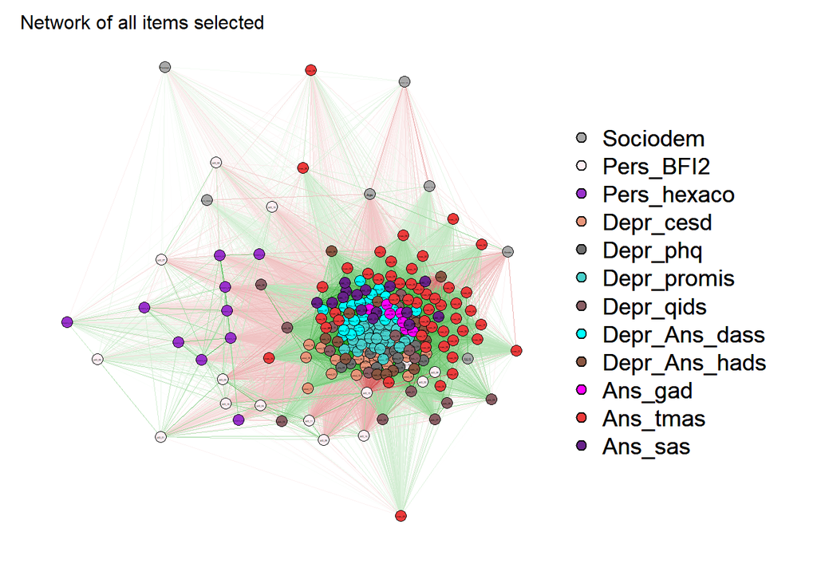

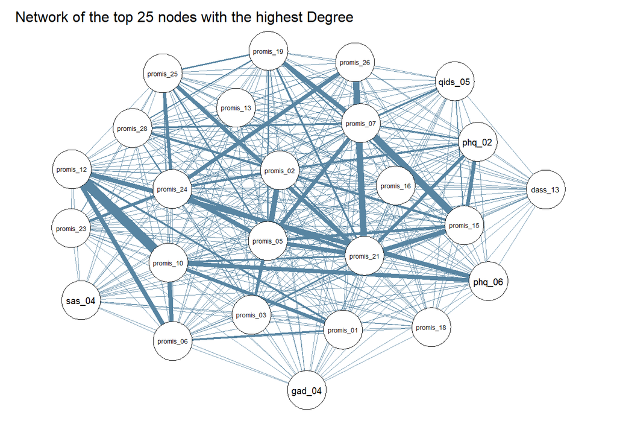

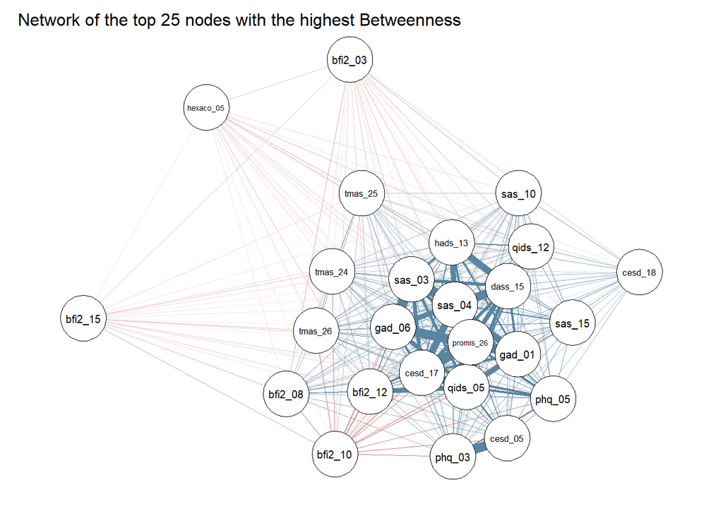

[figure not shown]

```r
all_cent_measures_25_top$selected_degree[1:5]
```

```
##           OutDegree  InDegree   Closeness Betweenness InExpectedInfluence
## promis_28 102.73187 102.73187 0.001651654         132            96.80786
## promis_05 102.67265 102.67265 0.001634279          20            95.81406
## promis_15 102.34382 102.34382 0.001625055          18            96.26238
## promis_21 101.91404 101.91404 0.001624916          66            95.38799
## promis_07 101.48832 101.48832 0.001632461          20            95.57241
## promis_02 100.71535 100.71535 0.001621166          10            94.11978
## promis_10 100.49144 100.49144 0.001611313          40            93.97657
## promis_24 100.32578 100.32578 0.001604322           4            94.11796
## promis_16 100.21900 100.21900 0.001620610          62            93.54996
## promis_03 100.15196 100.15196 0.001611138          10            94.19351
## promis_25  99.89986  99.89986 0.001617027          92            93.28973
## promis_19  99.82578  99.82578 0.001610316          60            93.68063
## phq_02     99.80981  99.80981 0.001604704          10            93.64015
## promis_26  99.51935  99.51935 0.001596339         256            93.24156
## qids_05    99.40587  99.40587 0.001622153         290            93.03823
## promis_12  99.37254  99.37254 0.001601848         106            92.46318
## dass_13    99.25572  99.25572 0.001614271          64            92.99601
## sas_04     99.17646  99.17646 0.001618604         372            92.91849
## phq_06     98.85536  98.85536 0.001593756          30            92.85065
## promis_18  98.66060  98.66060 0.001598793           2            92.51279
## promis_23  98.60162  98.60162 0.001586869         128            92.71222
## promis_13  98.48086  98.48086 0.001590487           6            91.92906
## promis_06  97.61451  97.61451 0.001584826           2            90.86067
## promis_01  97.49928  97.49928 0.001573437          10            91.48575
## gad_04     97.43461  97.43461 0.001602723         160            91.94606
```

```r
all_cent_measures_25_top$selected_betweenness[1:5]
```

```
##           OutDegree InDegree    Closeness Betweenness InExpectedInfluence
## bfi2_10    59.92890 59.92890 0.0011709930        1786           -53.20918
## tmas_26    69.74896 69.74896 0.0012917474         676            63.32791
## bfi2_12    81.10443 81.10443 0.0014347514         642            73.50471
## hads_13    86.58126 86.58126 0.0014899402         620            80.06767
## qids_12    75.26121 75.26121 0.0013438765         454            68.92153
## hexaco_05  25.18096 25.18096 0.0006590639         450           -16.85499
## gad_06     91.46422 91.46422 0.0015475565         422            85.11365
## tmas_25    53.41897 53.41897 0.0010641744         400            49.23132
## tmas_24    69.46999 69.46999 0.0012838729         392            63.56120
## bfi2_08    57.42446 57.42446 0.0011249789         390            50.23652
## sas_03     91.25993 91.25993 0.0015475791         376            84.72434
## sas_15     76.82753 76.82753 0.0013661980         376            71.66435
## sas_04     99.17646 99.17646 0.0016186045         372            92.91849
## phq_05     83.01792 83.01792 0.0014381009         362            78.63332
## cesd_17    96.63126 96.63126 0.0015827344         330            90.74286
## sas_10     63.55555 63.55555 0.0012013167         326            58.23398
## dass_15    90.22692 90.22692 0.0015186793         324            83.80752
## phq_03     76.46522 76.46522 0.0013528485         318            72.62299
## gad_01     92.51451 92.51451 0.0015525024         300            87.24896
## bfi2_03    22.42554 22.42554 0.0006927840         290           -14.10539
## qids_05    99.40587 99.40587 0.0016221530         290            93.03823
## promis_26  99.51935 99.51935 0.0015963387         256            93.24156
## cesd_18    52.02899 52.02899 0.0010462610         252            48.33391
## cesd_05    78.61580 78.61580 0.0013822979         248            74.00494
## bfi2_15    19.43378 19.43378 0.0006748649         232           -12.48344
```

```r
all_cent_measures_25_top$selected_closeness[1:5]
```

```
##                   OutDegree  InDegree    Closeness Betweenness
## Province           4.837275  4.837275 0.0003429635           0
## hexaco_09          7.711456  7.711456 0.0004121960           4
## tmas_08            6.885888  6.885888 0.0004303996           0
## bfi2_06            9.027465  9.027465 0.0004310463           8
## Education_Level    7.684890  7.684890 0.0004439484           4
## Civil_Status      11.378962 11.378962 0.0004728870           0
## hexaco_01         13.551735 13.551735 0.0004796096          10
## tmas_49           12.869103 12.869103 0.0004866866           0
## tmas_36           13.932397 13.932397 0.0005280199          10
## hexaco_06         17.277583 17.277583 0.0005299276          16
## Employment_Status 18.818980 18.818980 0.0005301994           2
## bfi2_05            9.230862  9.230862 0.0005603748           2
## hexaco_02         19.511797 19.511797 0.0005650682          14
## bfi2_01           11.910724 11.910724 0.0005717779          24
## bfi2_13           17.809722 17.809722 0.0005922594           0
## hexaco_04         19.311359 19.311359 0.0005952158           0
## tmas_15           23.459093 23.459093 0.0006018906           2
## hexaco_07         19.760071 19.760071 0.0006042270          32
## bfi2_07           11.208855 11.208855 0.0006065884          34
## hexaco_03         20.915313 20.915313 0.0006193033          12
## Age               21.677540 21.677540 0.0006231572          80
## hexaco_10         25.513979 25.513979 0.0006380295         124
## Gender            22.323511 22.323511 0.0006560089           6
## hexaco_05         25.180958 25.180958 0.0006590639         450
## tmas_01           27.269463 27.269463 0.0006695893           0
##                   InExpectedInfluence
## Province                    0.5136275
## hexaco_09                   4.0929930
## tmas_08                    -0.9812168
## bfi2_06                     6.2139015
## Education_Level            -5.1028005
## Civil_Status                8.6810319
## hexaco_01                  -6.4388898
## tmas_49                    10.4909034
## tmas_36                    11.3708767
## hexaco_06                  -9.9416089
## Employment_Status          16.7313038
## bfi2_05                    -3.8278565
## hexaco_02                 -11.2589738
## bfi2_01                    -2.3924347
## bfi2_13                   -14.2491095
## hexaco_04                 -15.1490845
## tmas_15                    21.2823520
## hexaco_07                 -13.4144700
## bfi2_07                    -6.0593324
## hexaco_03                 -15.2748325
## Age                       -17.5820431
## hexaco_10                 -17.0169808
## Gender                    -20.7073679
## hexaco_05                 -16.8549915
## tmas_01                    24.4337058
```

#### Depression and Anxiety Scales

```r
anx_dep_cent_measures_25_top <- FR_net_by_scales_topnum_measures(df, list(Depr_cesd = 34:53, Depr_phq = 54:63, Depr_promis = 64:91, Depr_qids = 92:108, Depr_Ans_dass = 108:128, Depr_Ans_hads = 129:142, Ans_gad = 143:149, Ans_tmas = 150:199, Ans_sas = 200:214), 25)
```

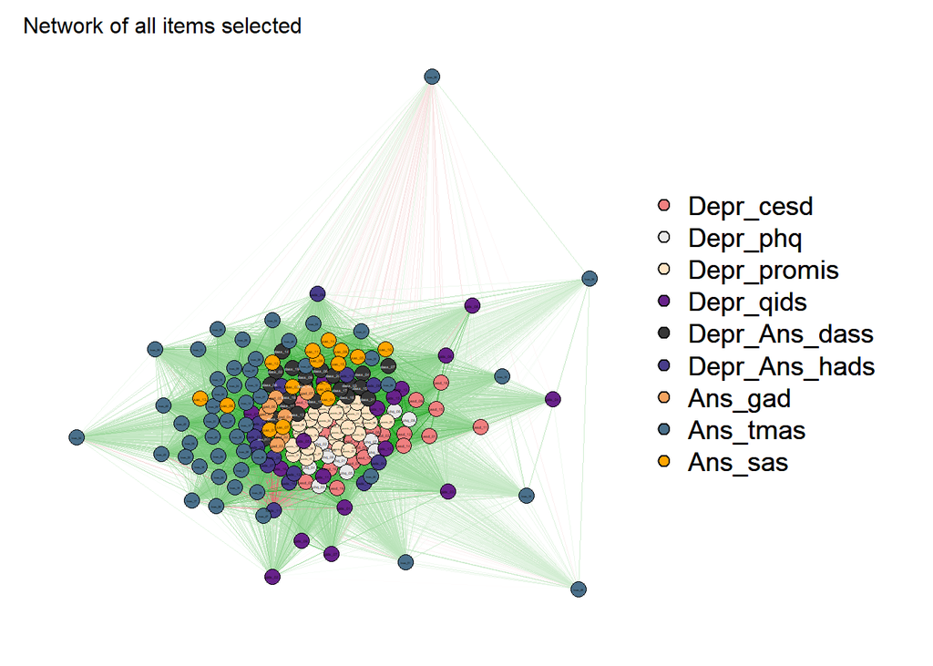

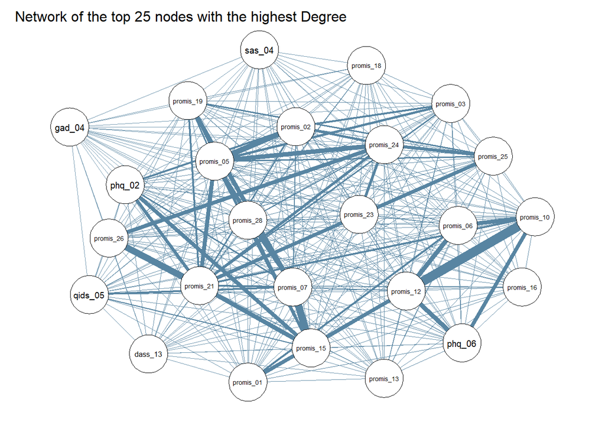

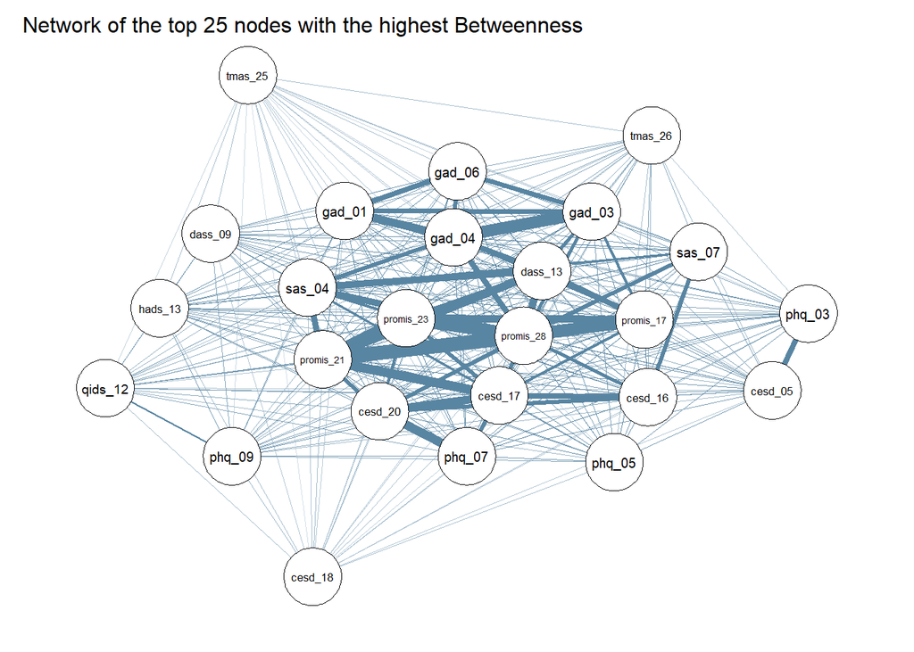

[figure not shown]

```r
anx_dep_cent_measures_25_top$selected_degree[1:5]
```

```
##           OutDegree InDegree   Closeness Betweenness InExpectedInfluence
## promis_28  98.17550 98.17550 0.002528432          70            97.44480
## promis_05  97.68283 97.68283 0.002487957          12            97.00822
## promis_15  97.59645 97.59645 0.002477123          14            96.93938
## promis_21  97.06442 97.06442 0.002463835          48            96.45394
## promis_07  96.73911 96.73911 0.002478153          20            96.04422
## promis_02  95.75856 95.75856 0.002457730          10            95.10203
## promis_24  95.67708 95.67708 0.002436928           4            94.98160
## promis_10  95.53752 95.53752 0.002439301          40            94.91717
## promis_03  95.47956 95.47956 0.002448064           8            94.94651
## promis_16  95.33713 95.33713 0.002466719          34            94.67518
## promis_19  95.08876 95.08876 0.002435145          10            94.32698
## phq_02     95.07088 95.07088 0.002422394          10            94.50250
## promis_25  94.89652 94.89652 0.002431588          14            94.28655
## promis_26  94.86291 94.86291 0.002415946          36            94.30126
## sas_04     94.58818 94.58818 0.002461973         196            93.95279
## dass_13    94.49559 94.49559 0.002451149          52            93.81503
## qids_05    94.49430 94.49430 0.002445280          26            93.81020
## promis_12  94.26208 94.26208 0.002409081           2            93.64945
## promis_23  94.19810 94.19810 0.002417550         128            93.52575
## phq_06     94.11132 94.11132 0.002408868          26            93.56143
## promis_18  94.03285 94.03285 0.002421769           2            93.44409
## promis_13  93.71378 93.71378 0.002398644           2            93.14086
## gad_04     93.14491 93.14491 0.002445063         154            92.27176
## promis_01  92.94107 92.94107 0.002381144          10            92.40155
## promis_06  92.72168 92.72168 0.002393795           2            92.17022
```

```r
anx_dep_cent_measures_25_top$selected_betweenness[1:5]
```

```
##           OutDegree InDegree   Closeness Betweenness InExpectedInfluence
## tmas_26    65.32676 65.32676 0.001815881         376            64.81551
## tmas_25    50.64971 50.64971 0.001470732         358            50.24676
## phq_05     79.36681 79.36681 0.002119827         300            78.76960
## cesd_17    92.00871 92.00871 0.002377435         288            91.50352
## gad_06     86.77192 86.77192 0.002306015         270            86.07075
## cesd_18    49.58911 49.58911 0.001436286         222            49.20701
## cesd_05    74.98426 74.98426 0.002016263         198            74.31072
## sas_04     94.58818 94.58818 0.002461973         196            93.95279
## sas_07     87.39530 87.39530 0.002331850         168            86.74120
## gad_04     93.14491 93.14491 0.002445063         154            92.27176
## promis_23  94.19810 94.19810 0.002417550         128            93.52575
## hads_13    82.21764 82.21764 0.002203010         104            81.59295
## gad_03     89.76687 89.76687 0.002359959          98            89.06193
## phq_09     73.68320 73.68320 0.001935355          84            73.28548
## phq_07     85.97915 85.97915 0.002254195          76            85.33957
## promis_17  92.35035 92.35035 0.002382233          70            91.65750
## promis_28  98.17550 98.17550 0.002528432          70            97.44480
## phq_03     73.18761 73.18761 0.001960973          66            72.57242
## gad_01     88.31733 88.31733 0.002345515          64            87.45186
## dass_13    94.49559 94.49559 0.002451149          52            93.81503
## promis_21  97.06442 97.06442 0.002463835          48            96.45394
## qids_12    71.06083 71.06083 0.001899834          46            70.55925
## dass_09    83.71554 83.71554 0.002221526          46            83.11040
## cesd_16    84.40321 84.40321 0.002226320          42            83.82525
## cesd_20    89.92170 89.92170 0.002345136          40            89.35033
```

```r
anx_dep_cent_measures_25_top$selected_closeness[1:5]
```

```
##         OutDegree  InDegree    Closeness Betweenness InExpectedInfluence
## tmas_08  5.793085  5.793085 0.0005338798           0          -0.9017463
## tmas_49 11.555846 11.555846 0.0006074217           0          10.8579099
## tmas_36 12.480951 12.480951 0.0006598133           4          12.1198045
## tmas_15 21.877775 21.877775 0.0007649391           0          21.6868757
## tmas_01 25.163859 25.163859 0.0008580324           0          24.9141919
## qids_04 22.893613 22.893613 0.0008741754           0          22.6598763
## tmas_34 24.143216 24.143216 0.0008850638           0          23.5845837
## qids_08 25.330646 25.330646 0.0008984924           0          24.5048702
## qids_02 26.659264 26.659264 0.0009943540           0          26.2817911
## tmas_16 30.465282 30.465282 0.0010195889           0          29.9685400
## tmas_06 33.603273 33.603273 0.0010335818           0          33.2413321
## qids_03 35.715970 35.715970 0.0010950694           0          35.3191616
## qids_07 31.873464 31.873464 0.0010968700           0          31.0324060
## qids_09 35.884032 35.884032 0.0011020337           2          34.9333452
## hads_09 36.773678 36.773678 0.0011324214           0          36.3762316
## tmas_17 37.813581 37.813581 0.0011800147           0          37.4251010
## cesd_11 38.036511 38.036511 0.0012035149           2          37.6412197
## tmas_20 41.001788 41.001788 0.0012180912           0          40.5699092
## qids_06 40.963512 40.963512 0.0012366172          12          39.8034247
## tmas_43 42.681584 42.681584 0.0012708771           0          41.8390482
## tmas_45 43.178663 43.178663 0.0012869741          10          42.5220856
## tmas_04 43.917152 43.917152 0.0012944601           2          43.5153497
## tmas_11 43.981436 43.981436 0.0012972171           6          43.5182416
## tmas_35 44.124080 44.124080 0.0013217308           0          43.4621634
## tmas_47 45.590008 45.590008 0.0013494499          14          45.2381375
```

## Multidimensional Scaling (MDS) of Networks

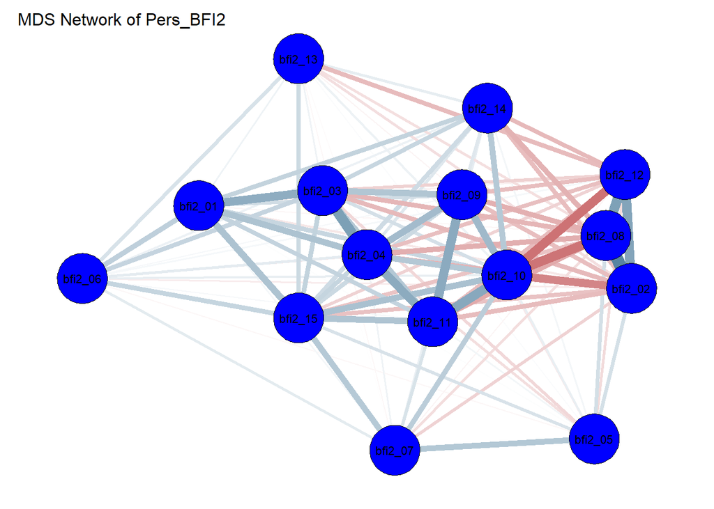

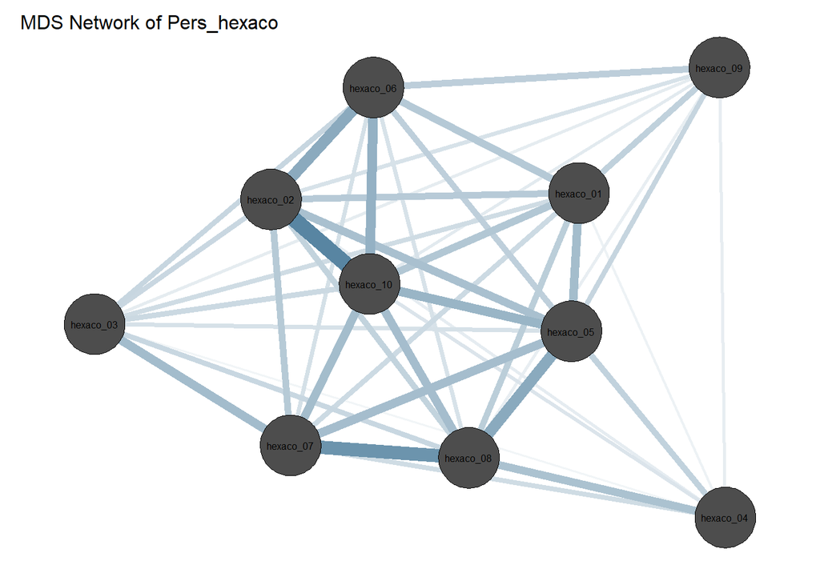

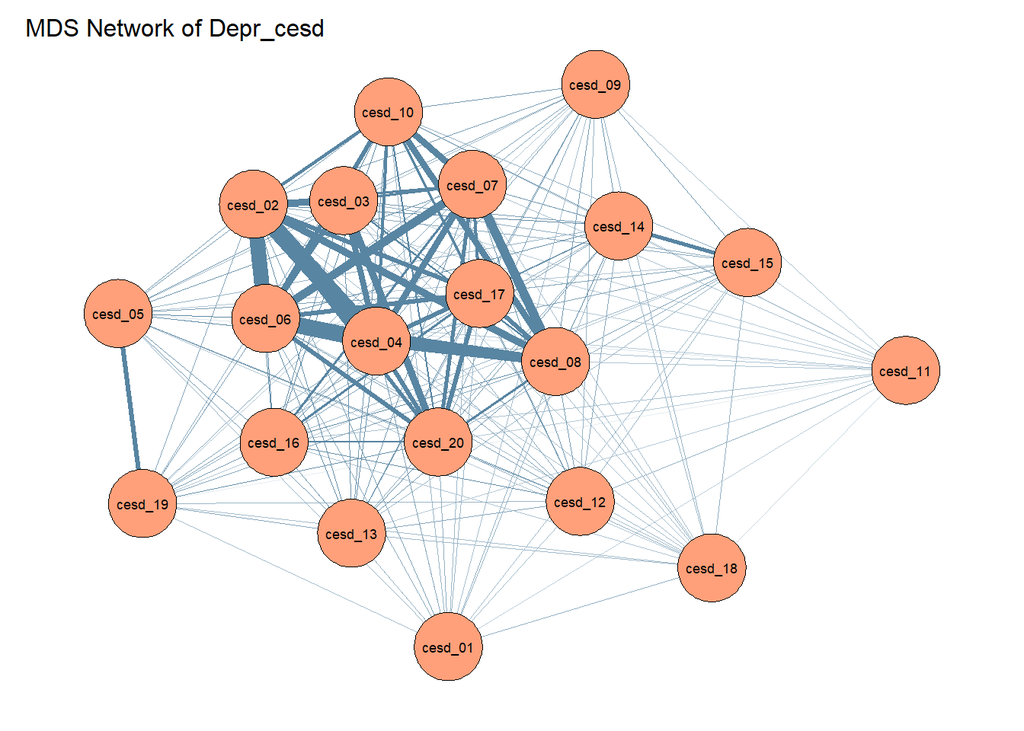

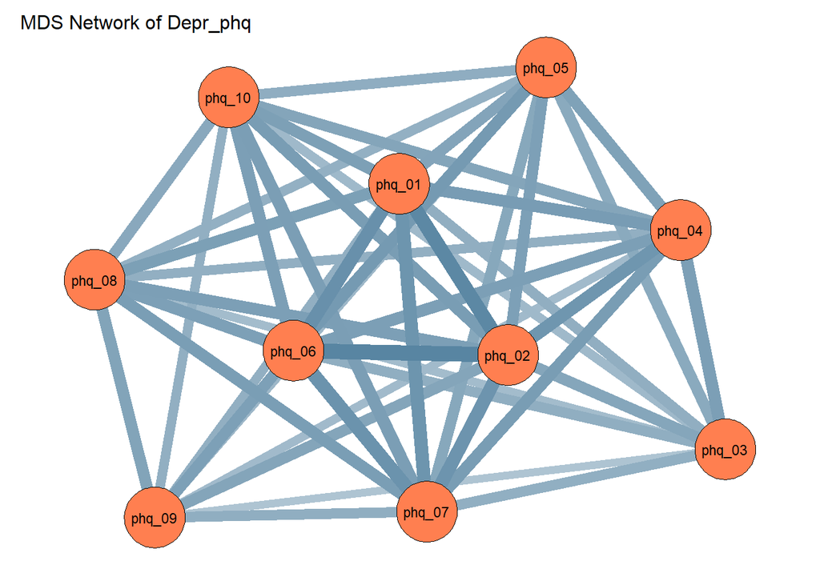

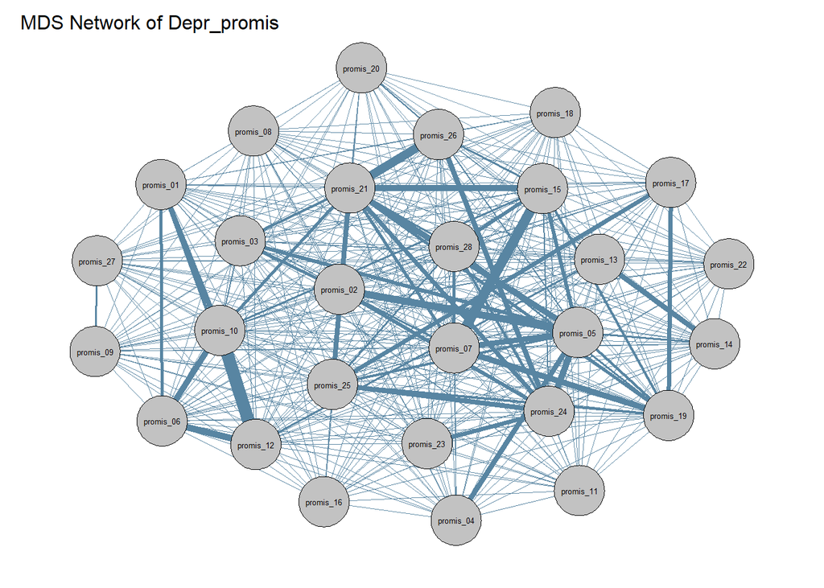

[figure not shown]

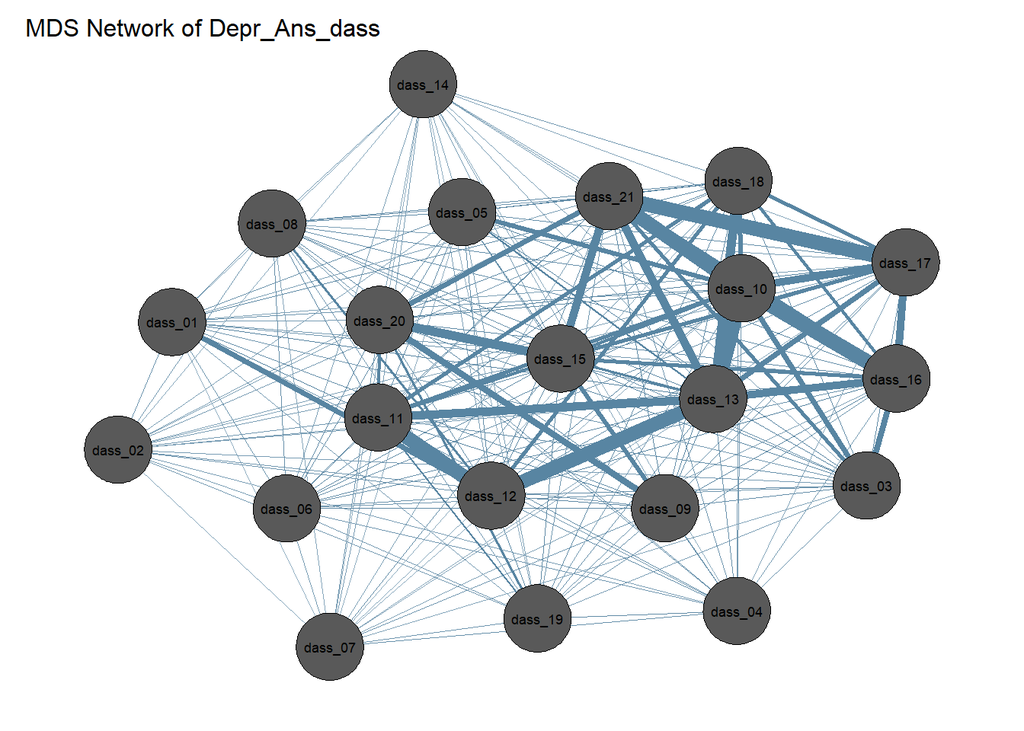

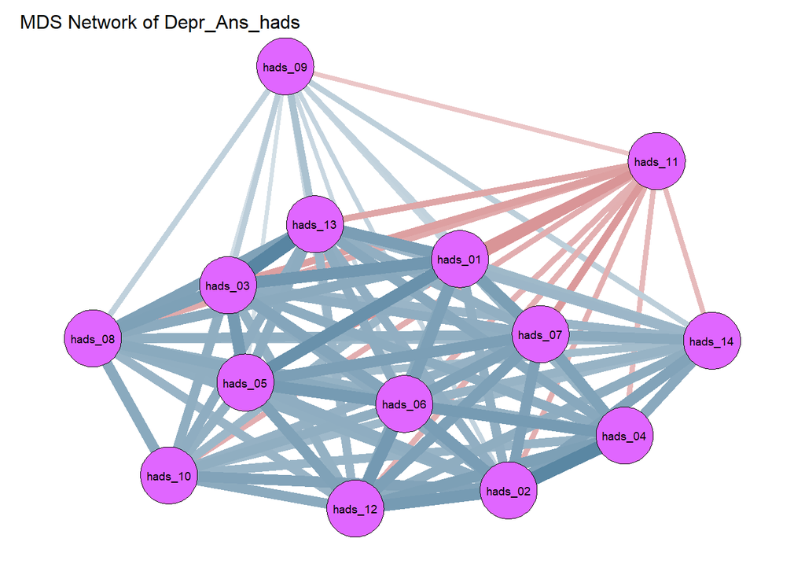

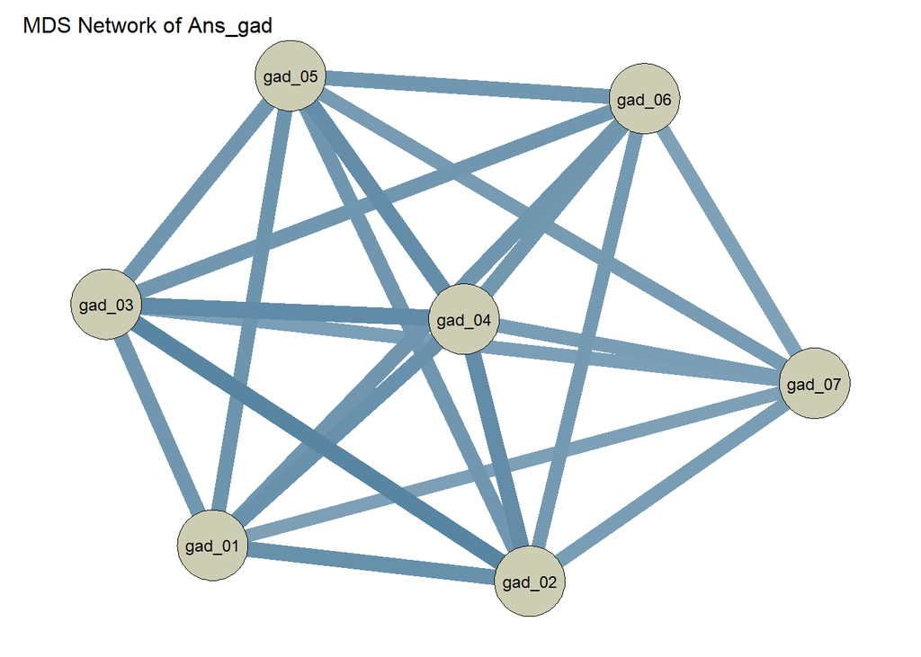

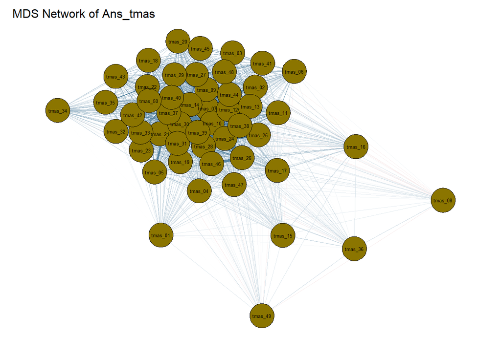

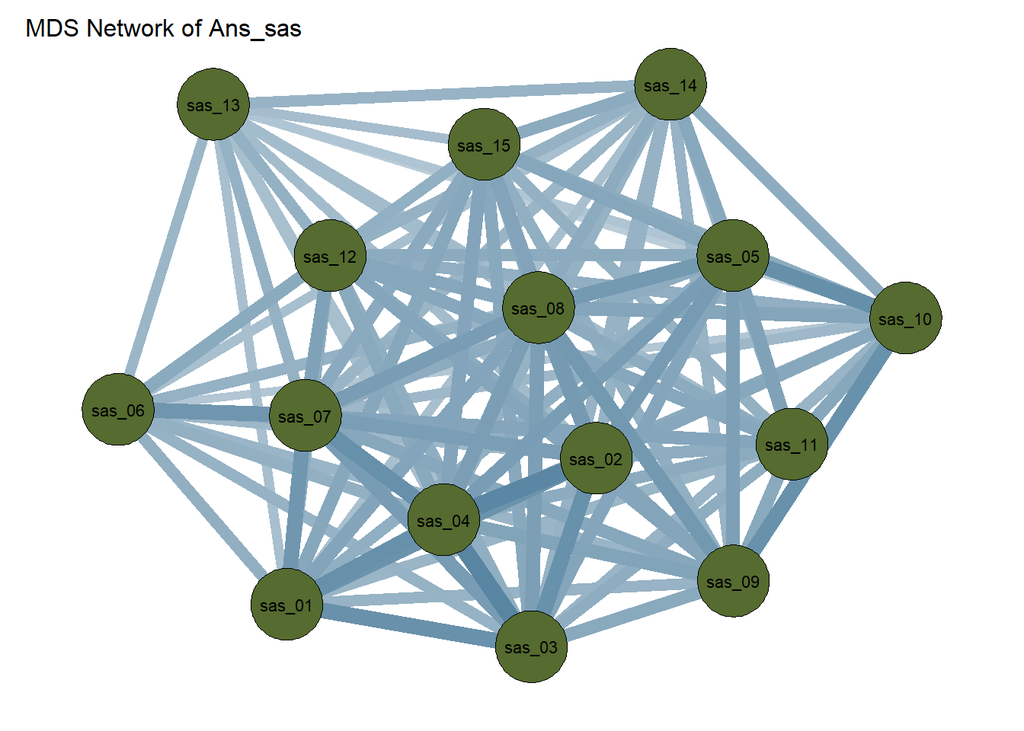

```r
groups <- list(Pers_BFI2 = 9:23, Pers_hexaco = 24:33, Depr_cesd = 34:53, Depr_phq = 54:63, Depr_promis = 64:91, Depr_qids = 92:108, Depr_Ans_dass = 108:128, Depr_Ans_hads = 129:142, Ans_gad = 143:149, Ans_tmas = 150:199, Ans_sas = 200:214)

n <- 3
for(sc in groups){
  zero_order_md <- cor(df[sc])
  qgraph(zero_order_md, layout="spring", labels = colnames(zero_order_md), color = sample(colors(), 1), theme="TeamFortress", height = 180, width = 140, title = paste("MDS Network of", group_names[n]))
  n <- n + 1
}
```